# **Placement Logbook: Alfred Wegener Institute**

Fraser Campbell

# 1 26/09/2022: First two weeks

These first two weeks have been exciting, lonely, and exhausting. This internship is at the “Alfred Wegener Institute for Polar and Marine Research” (AWI) in Germany, in a small city called Bremerhaven. The biggest challenge so far has certainly been the culture shock. My coworkers speak excellent English, since I believe it’s a requirement when working in science, but around the city it’s much more rare. As such, I’ve found it hard to meet new people, and more often than not find myself alone, reflecting on the day with my own thoughts. In addition, my coworkers all live in Bremen, a much larger city nearby, and commute in, so it’s very difficult to arrange any kind of social activities after work. Also, it rains rather a lot here.

[interactive chart not shown]

Despite this veritable myriad of difficulties, I’m having a good time. Being in a brand new place is nerve wracking, but exciting, and I’m keeping busy with exercise, visiting new places, and, of course, my work. Speaking of…

## 1.1 What have I done so far?

My position is as an intern in Prof. Dr. Bettina Meyer’s working group, “Ecophysiology of Pelagic Key Species”. Her primary interest is Antarctic krill, *Euphausia superba*, and their role in the ecosystem of the Southern Ocean. The project which I’m working on aims to gain a mechanistic understanding of Antarctic krill overwintering methods (how they survive being covered by sea ice), specifically looking at how lipid reserves affect this.

I’ve been working with a very large data set, which Bettina is excited about - apparently we’ve never had data at this resolution before! Here’s a little taste:

| Date | Vessel | Lipids | RawKrill_Visual_GreenHeads | Size | Weight | Position | Area |
| --- | --- | --- | --- | --- | --- | --- | --- |
| 44588 | Antarctic Endurance | 31.17387 | No | 38.12 | 0.43 | 60°35S45°18W | 48.2 |
| 44559 | Antarctic Endurance | 27.44099 | Slightly green | 41.08 | 0.62 | 60°12S47°07W | 48.2 |
| 44604 | Antarctic Sea | 29.65241 | Slightly green | 47.60 | 0.83 | 60°04S47°04W | 48.2 |
| 44558 | Saga Sea | 28.58589 | Yes | 40.81 | 0.57 | 60°08S47°05W | 48.2 |
| 44549 | Saga Sea | 42.41370 | Yes | 53.90 | 1.31 | 60°24S45°55W | 48.2 |
| 44567 | Saga Sea | 27.72753 | Yes | 38.08 | 0.42 | 60°17S46°01W | 48.2 |

Fun! This data is collected from fisheries, who harvest krill as a source of omega-3. In fact, that’s what the “Lipids” column contains - the amount of omega-3 (in mg) from that krill catch. This is the column I’ve been focused on. As Bettina explained to me, before we start any real analysis, it’s a good idea to understand what this data is showing us; which years have the most lipid content? Do we have data for each month? What’s the proportion of lipid content between months?

To this end, my tasks for the past few weeks have been to visualise this data in an accessible and intuitive way. To start, Bettina suggested that I create pie charts for each year. Easy, right? Well, not exactly. Unfortunately, the graph package that I like, ggplot, does not have a function to make pie charts. To make one, you have to create a stacked bar chart, then change the coordinates to modify how the graph is plotted. As a result, doing anything to the final product (such as adding labels or reordering the slices) is way more complicated. Moreover, since I needed a pie chart for every year, this process had to be automated with a loop (lest I wanted to sit in this office typing the same code 10 times). Fortunately, I really enjoy this kind of stuff! Here’s the whistle-stop tour of my process.

### 1.1.1 Krill lipid pie charts

To start, I tested making a pie chart with just one year, before throwing my code into a big slow loop. After a day of trial and error (the most difficult part, incredibly, being changing the order of the slices), I had a successful pie chart.

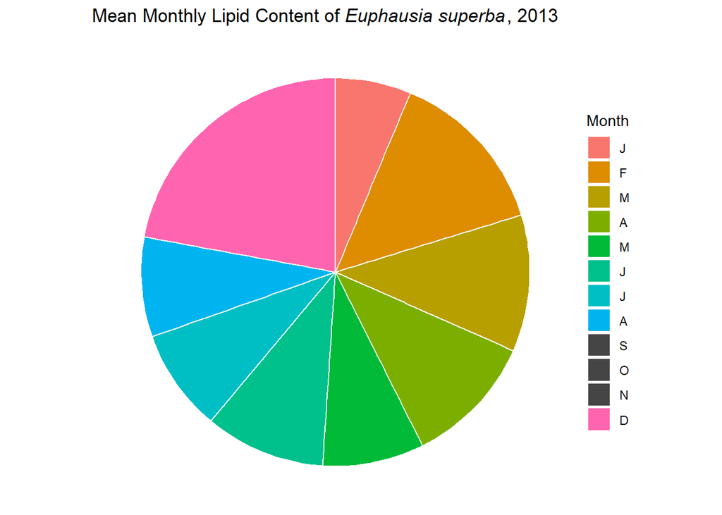

Ideal! Next came making the loop and adding labels, which took way less time.

```r
for (i in years){
  krill_pal = hue_pal()(12)
  remove(krillYEAR,krillPie,tempMonth,labelPos)
  krillYEAR = dplyr::filter(krill,grepl(as.character(i),date.YMD)) # Filters the whole data set to just use one year at a time
  for (j in krillYEAR$date.YMD){ # Extacts the month from each date, so we can more easily differentiate between them
    krillYEAR$specMonth=(stri_sub(krillYEAR$date.YMD,6,7))
    monthlyLipids = data.frame()
    badMonth = c()
    n=1

    #This section sums up each month's total lipids and puts them into a separate data frame
    #This means that we can more clearly visualise the separation between months
    for (u in monthNums){
      tempMonth = dplyr::filter(krillYEAR,grepl(u,specMonth))
      monthSum = sum(tempMonth$Lipids,na.rm=TRUE)
      monthMean = monthSum/length(tempMonth$specMonth)
      if (((is.nan(monthMean)==TRUE|(monthMean==0)==TRUE))==TRUE){ # Surely there's an easier way to do this? Oh well...
        monthlyLipids = rbind(monthlyLipids,c(0,u,i))
        krill_pal[as.numeric(u)] = "#454545"
        badMonth[n] = as.numeric(u)
        n=n+1
      } else {
        monthlyLipids = rbind(monthlyLipids,c(monthMean,u,i))}
    }

    # Housekeeping; We like tidy tables!
    colnames(monthlyLipids) = c("lipidMean","Month","Year")
    monthlyLipids$lipidMean = as.numeric(monthlyLipids$lipidMean)
    monthlyLipids$Month = as.factor(monthlyLipids$Month)
    monthlyLipids$Year = as.character(monthlyLipids$Year)

    # Calculate the position of the labels
    labelPos = monthlyLipids %>%
      mutate(csum = rev(cumsum(rev(lipidMean))),
             pos = lipidMean/2 + lead(csum, 1),
             pos = if_else(is.na(pos), lipidMean/2, pos,))
    labelPos$pos[badMonth] = NA

    # Make the plot
    krillPie = ggplot(monthlyLipids,aes(x=Year,y=lipidMean,fill=Month)) +
      geom_bar(stat="identity",
               width=1,
               color="white") +
      coord_polar("y",start=0,direction=-1,clip="off") +
      theme_void() +
      scale_fill_manual(labels=c(allMonths),values=krill_pal) +
      geom_label_repel(labelPos, mapping=aes(y=pos, label=paste0(round(lipidMean,digits=2),"mg")),
                       size = 6.5, nudge_x = 0.7, show.legend = FALSE, na.rm = TRUE) +
      ggtitle(i,subtitle=paste(as.character(round((sum(krillYEAR$Lipids,na.rm=TRUE)/1000),digits=2)), "g total")) + theme(plot.title = element_text(size = 22, face = "bold"), plot.subtitle = element_text(size = 19.5), legend.key.height=unit(0.5,"cm"),legend.title=element_text(size=18,face="bold"),legend.text=element_text(size=17))
    assign(paste0("krill",i),krillPie)
  }
}
```

With each pie chart neatly stored into its own variable, they can be plotted all together as a lovely big graph.

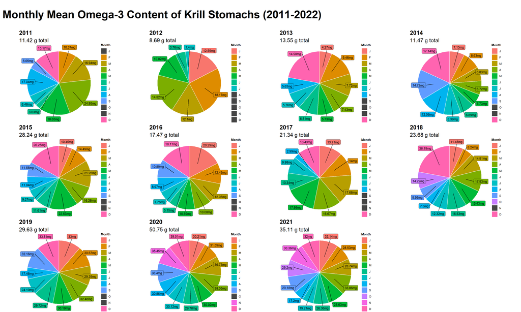

And that concluded my first week! I’m incredibly happy that I was able to work out how to create this graph, since I was a bit rusty with my R. I think the last time I really sunk my teeth into this kind of project was in my MBIO227 coursework, with the data we collected in Sweden. The biggest challenge was understanding how R handles data frames - it tends to do so in the most backwards and un-intuitive way possible, so reigning it in and making it do what I actually wanted was frustrating. However, as always, this was a rewarding process; I finished my first week understanding a lot more about data handling packages, base R, and, of course, Antarctic krill.

### 1.1.2 Comparing specific months

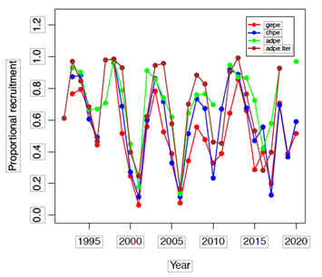

Now that we had an idea of how the lipid levels vary year-by-year, the natural next step was to investigate in more detail. Krill spawn in Austral spring (August/September-ish), and their success depends on their lipid stores, which they use as a source of energy.

Bettina was interested in discovering whether or not the changes in lipid levels between the Austral spring of each year had any correlation with years of high and low krill biomass. I don’t yet have access to the yearly krill recruitment data (although I was provided with this tiny graph (right)). In the meantime, I plotted a bar graph to visualise how the mean lipid content of June-September changes with each year. What I expected to see was the bar heights roughly matching the pattern in the krill recruitment graph…

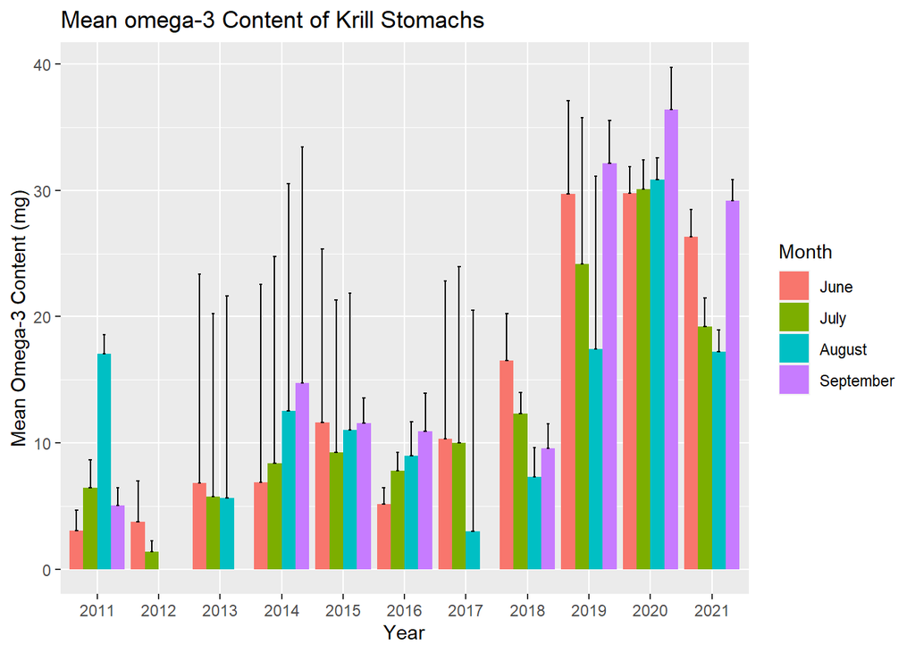

```r
inspectaMonth = "06 07 08 09" %>%
  strsplit("[[:space:]]") %>%
  unlist()
seasonalLipids = data.frame()
for (i in years){
  krillYEAR = dplyr::filter(krill,grepl(as.character(i),date.YMD))
  for (j in inspectaMonth){
    MONTHkrill = dplyr::filter(krillYEAR,grepl(paste0("-",j,"-"),date.YMD))
    MONTHsum = sum(MONTHkrill$Lipids,na.rm=TRUE)
    MONTHmean = MONTHsum/length(MONTHkrill$date.YMD)
    MONTHsd = sd(MONTHkrill$Lipids,na.rm=TRUE)
    seasonalLipids = rbind(seasonalLipids,c(i,MONTHmean,j,MONTHsd))
  }
}

colnames(seasonalLipids) = c("Year","Lipids","Month","SD")
seasonalLipids$Lipids = as.numeric(seasonalLipids$Lipids)
seasonalLipids$Month = as.factor(seasonalLipids$Month)
seasonalLipids$SD = as.numeric(seasonalLipids$SD)
seasonalLipids[seasonalLipids==0] = NA

krillCocktail = ggplot(seasonalLipids,aes(x=Year,y=Lipids,fill=Month)) +
  geom_bar(stat="identity",position=position_dodge(0.9)) +
  scale_fill_discrete(labels=allMonthsLong[as.numeric(inspectaMonth)]) +
  geom_errorbar(aes(ymin=Lipids,ymax=Lipids+SD),position=position_dodge(0.9),width=0.2) +
  ggtitle("Mean omega-3 Content of Krill Stomachs") +
  labs(y="Mean Omega-3 Content (mg)")
krillCocktail
```

Yeah, kind of! There looks like a rough up-down wave in that graph. I showed this to Bettina, and she seemed concerned about the standard deviation on some of those years as well as the sharp increase in lipid measurements from 2019 onwards. She suggested this may be something to do with the fisheries changing their sampling and measurement methods, but she’s going to double check that. In addition, she suggested that I inspect just August, as this is the month when we would expect the most lipids to be present (because they’re about to spawn, so they need lipids for a whole bunch of internal processes). Here’s that graph:

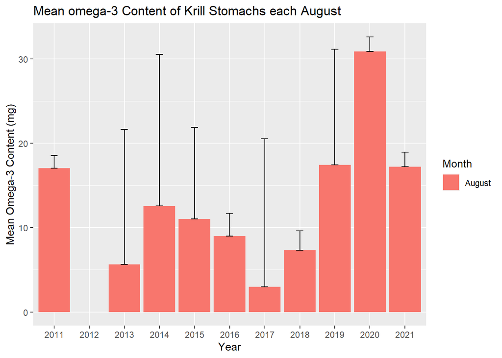

# 2 30/09/2022: Rmarkdown, Git, and insignificant statistics

This little entry is a bit of a meta one, since I spent a lot of this week creating what you’re reading now. I finished with all of the data visualisation (which Bettina was pleased with) and I had no access to the krill biomass data (which I need to move forward with any meaningful analysis). So, I decided *not* to spend the whole week refreshing twitter, and instead learn a slightly new language; Rmarkdown.

## 2.1 Rmarkdown

Rmarkdown is essentially a format of document that can make aesthetically pleasing (and reproducible!) documents to summarise your data, and allows the user to explain their methods alongside their analysis. I’ve been interested in learning it for a little while, and making this logbook was a great opportunity to make something meaningful at the same time! It’s been genuinely quite a lot of fun to explore what I can do with Rmarkdown. Frustrating at times too, of course (it’s still R, after all), but well worth the time spent in it!

One thing I haven’t yet been able to achieve is interactive graphs. I wanted to make the “Mean Monthly Lipids” graph interactive, so that people reading this document could input different months and see how the lipid content changed. This is absolutely possible, and uses a different framework called “shiny”. Shiny is quite similar to HTML and Javascript, both of which I’ve struggled to learn in the past. In the coming weeks I’ll keep plugging away at shiny, and try to wrap my head around a new syntax and workflow.

## 2.2 Git

Speaking of old languages and coding I’ve tried in the past, I decided to try Git/Github again too! Funnily enough, I was introduced to git around the same time as HTML/Javascript (during *another* work placement, in Year 12, at [Dennis Publishing](https://en.wikipedia.org/wiki/Dennis_Publishing)).

This time, I took it slowly, relearnt the basic tools, and successfully set up [a repository](https://github.com/campbellfraser/AWI-krill) to upload all of my work during this internship. I think it’s a bit easier this time around because I can consistently add to it, so I’m repeatedly practicing the process.

## 2.3 Insignificant statistics

And to conclude this week, I did some very basic and incredibly boring statistics! I wanted to take a look at the monthly mean lipid data from an analytical standpoint; specifically, I wanted to find out if there was any kind of significant difference between the means of each August. To test that, I need to do a 1-Way ANOVA. Now, running that test is easy - meeting the assumptions is the tricky part.

The data has to be both normal and homogeneous, which we test for with a Shapiro-Wilk test and Levene’s Test respectively.

```r
shapiro.test(seasonalLipids$Lipids)
```

```
##
##  Shapiro-Wilk normality test
##
## data:  seasonalLipids$Lipids
## W = 0.91641, p-value = 0.328
```

```r
leveneTest(Lipids~Year,seasonalLipids)
```

```
## Levene's Test for Homogeneity of Variance (center = median)
##       Df F value Pr(>F)
## group  9     NaN    NaN
##        0
```

From the p-values, we know that our August lipid data is normal (p-val > 0.05), but Levene’s test doesn’t return a value for homogeneity. I’m not sure why - I think it might be to do with there only being one month to compare each year, but I don’t know why it would be upset with that. Since I can’t verify whether this data is homogeneous, I couldn’t do a regular ANOVA, so I turned to the non-parametric alternative, Kruskal-Wallis.

```r
kruskal.test(Lipids~Year,seasonalLipids)
```

```
##
##  Kruskal-Wallis rank sum test
##
## data:  Lipids by Year
## Kruskal-Wallis chi-squared = 9, df = 9, p-value = 0.4373
```

Yep, no significant difference between any of those means (p-val > 0.05). Of course, this test is less powerful, so these results aren’t 100% reliable. Oh well! That’s all for this week. It’s a really nice day outside, so I’m going to read in the park.